# 1_Read and Explore and Clean the data with R-tidyverse

Tran Le

08 August, 2021 Updated on 14 September, 2021

```r
knitr::opts_chunk$set(echo = TRUE, collapse=TRUE, comment=">>")
library(tidyverse) #to use with many purpose: data wrangling
library(dplyr )
library(h2o)
library(visdat)  # to visualize missing values
library(mice)
library(Hmisc)  # to draw histogram of all column in a R data frame
source("./Utilities.R") # need to list the source to the Utilities.R file that keeps function used in this file
```

# 1 Introduction

This project uses the House Prices data gotten from [Kaggle](https://www.kaggle.com/c/house-prices-advanced-regression-techniques).

I have seen people in Kaggle use Linear Regression, Generalized Linear Regression, XGBoost, Support Vector Machine, … This article is about using [Auto Machine Learning (AutoML) with package h2o](https://docs.h2o.ai/h2o/latest-stable/h2o-docs/automl.html). Here is [link to the project on my GitHub page](https://github.com/tranktle/ml_with_r_h2o) where you can download code from the folder named `ml_with_r_h2o`

Based on the [h2o’s documentation](https://docs.h2o.ai/h2o/latest-stable/h2o-docs/automl.html): “The current version of AutoML trains and cross-validates the following algorithms (in the following order): three pre-specified XGBoost GBM (Gradient Boosting Machine) models, a fixed grid of GLMs, a default Random Forest (DRF), five pre-specified H2O GBMs, a near-default Deep Neural Net, an Extremely Randomized Forest (XRT), a random grid of XGBoost GBMs, a random grid of H2O GBMs, and a random grid of Deep Neural Nets”. “AutoML then trains two Stacked Ensemble models, one from all of the models created, one from the best model from each algorithm class/family. Both of the ensembles should produce better models than any individual model from the AutoML run except for some rare cases.”

The advantage of using AutoML is it can help produce a better prediction. Besides, after fitting models, we can do the model explanation that can help recognize “important” factors that affect the outcomes and also how they affect the outcomes. ([Link to the“Interpretable Machine Learning” book](https://christophm.github.io/interpretable-ml-book/)).

My goal for this project is to provide a detailed explanation of how to use AutoML with data having a continuous outcome. All of the codes are put in functions with detailed explanations that can be conveniently used later on with other data. I will first write some simple code for exploring the data then jump into our main part, AutoML.

# 2 Utilities functions that will be used

I put utility functions on the file named `Utilities.R` and called `source("./Utilities.R")` to use these functions on this file. However, to make it easier to follow up, I also print these functions here. An explanation for how to create a function named `create_descrip_tibble_f` showing how to create a tibble that contains information from decription.txt is explained [here](https://htmlpreview.github.io/?https://github.com/tranktle/ml_with_r_h2o/blob/main/ml_with_r_h2o/code/2_WorkWithDescriptionFile.html#2_Explain_the_two_functions_above).

```r
# Function to observe missing values and list the column with missing values from highest to lowest
mis_value_listing_f <- function(data){
  #return num_missing, a data contains names of columns with missing values and percentage of missing values
  col_mis_values <- colnames(data)[colSums(is.na(data)) > 0]

  num_missing <- map(data %>% select((col_mis_values)), ~sum(is.na(.))) %>% as.data.frame
  num_missing <- num_missing %>%
    pivot_longer(everything(), names_to = "col_name", values_to =
                   "num_of_miss") %>% arrange(desc(num_of_miss)) %>%
    mutate(percent_miss = num_of_miss/(dim(data)[1]))
  return(num_missing)}
```

```r
# Function to create description tibble from data_description.txt
create_descrip_tibble_f <- function(){
  # Step 1: Create a tibble
  des_file <- read_lines("../house_dat/data_description.txt",
                         skip_empty_rows = TRUE)

  header <- c("name\tdescription\n")
  des_file <- str_c(header, des_file)

  des_file_new <- suppressWarnings(read_delim(des_file, delim = "\t")) %>%
    filter(name != "name") %>%
    mutate_if(is.character, str_trim)

  des_file <- des_file_new %>% mutate(index = 1:nrow(des_file_new))

  # Step2: Create num_fac, a column that distinguish which row is a numerical/factorial columns or factor levels
  # Find the indexes of columns
  col_index <- filter(des_file, grepl(':', name)) %>% pull(index)

  # Find indexes of numerical columns
  lag_diff <- diff(col_index, lag = 1, differences = 1)
  is_num_col <- (1==lag_diff)
  num_col_index <-  col_index[is_num_col]

  # Find the indexes of catergorical columns
  char_col_index <-  col_index[!is_num_col]
  # Add a column named num_fac to distingush between numeical, factorial column or factor_level_values

  des_file <- des_file %>%
    mutate(num_fac = case_when(
      index %in% num_col_index ~ "num_col",
      index %in% char_col_index ~ "fac_col",
      TRUE                      ~ "fac_val")) %>%
    select(index, everything())  #to put index column in the first column
  # Step 3: Correct the columnnames:description to put them into separated "name" and "description" columns
  work_with_col_name<- des_file %>% filter(index %in% col_index) %>%
    separate(col = name, into =c("name", "description"), sep=":")
  des_file <- rbind(des_file %>% filter(num_fac =="fac_val"), work_with_col_name) %>%
    arrange(index)

  return(des_file)
}
```

```r
# A function to find colnames of chacteristics columns having NA means "None"

find_col_name_f <- function(des_tibble){
  #Find the index values of rows having NA means "None"
  Na_index <- des_file %>% filter(name =="NA") %>% pull(index)

  #Filter the row index of column names
  Col_index <- des_file %>% filter(num_fac=="fac_col") %>% pull(index)

  # Find indexes of columns that contains NA means "None"
  Col_contain_Na_index <- c()
  for (i in Na_index){
    Col_contain_Na_index <- append(Col_contain_Na_index,max(Col_index[Col_index < i]) )}
  # Take names of columns that contains NA means "None" based on it indexes
  Thecolname <- des_file %>% filter(index %in% Col_contain_Na_index) %>% pull(name)
  return(Thecolname)
}
```

```r
#Funtions for imputing data-----------------------------------------------

# Function to impute the numerical columns with mean
replace_by_mean_f <- function(x) {
    x[is.na(x)] <- mean(x, na.rm = TRUE)
    return(x)}

# Function to impute characteristic columns according to the frequency
replace_na_categorical_f <- function(x) {
    my_df <<- x %>% table() %>% as.data.frame() %>% arrange(-Freq)

    n_obs <- sum(my_df$Freq)
    pop <- my_df$. %>% as.character()
    set.seed(29)
    x[is.na(x)] <- sample(pop, sum(is.na(x)), replace = TRUE, prob = my_df$Freq)
    return(x)}

# Function to impute the whole data set with mean for numerical columns
# and frequency for factorical columns
imp_mean_fre_f <- function(df, opt){
  # Impute df, use frequency for factorial columns, use mean/median for numerical columns
  # df: dataframe
  # opt = 1 for mean, opt=2 for using median
  if (opt==1){
    df <-  df %>%
      mutate_if(is.numeric, replace_by_mean_f) %>%
      mutate_if(is_character, replace_na_categorical_f)
  } else {
    df <-  df %>%
      mutate_if(is.numeric, replace_by_median_f) %>%
      mutate_if(is_character, replace_na_categorical_f)
  }
  return(df)}
```

# 3 Some note before working with the Project

1- You need to create a project on R. This is [how](https://support.rstudio.com/hc/en-us/articles/200526207-Using-Projects). It will make your project be much organized and make sure that your code, data, and results will not be mixed up together.

2- With this project, I first create a new project on a folder with the same name, let say `ml_with_r_h2o`. Then I will create a folder, named `code` that will contain all of the Rfile.script or Rfilename.Rmd that I will use. Also, create a folder named “house_dat” that contains train and test data. All of the files will be uploaded on my github account in the folder named ml_with_r_h2o. [Link to the ml_with_r_h2o folder](https://github.com/tranktle/ml_with_r_h2o).

3- It is better to read this article when you are familiar with data wrangling using tidyverse. A good book for studying is [R for Data Science](https://r4ds.had.co.nz/), or a more advanced book, [Advanced R](https://adv-r.hadley.nz/). Here are some things that I use in this project that you might found in these books or use the link provided:  
- How to reuse functions that you create in Scrips: use source of a function.  
- Using [glue](https://glue.tidyverse.org/) to write shorter and well-organized R code.

# 4 Read file, explore the data

First, read the data. Note that the output is SalePrice-the property’s sale price in dollars.

```r
train <- read_csv(file="../house_dat/train.csv")
test <- read_csv(file="../house_dat/test.csv")
```

Dimension of the train and test sets. We see from the below that the train set has one more column than the test set.

```r
cat("Dimension of the train set:", dim(train), "\n")
>> Dimension of the train set: 1460 81
cat("Dimension of the test set:", dim(test), "\n")
>> Dimension of the test set: 1459 80
```

Let’s see what column is in the train but the test set. We see that the column SalePrice (the output) is on the train but not test and all of the columns on the test set are in the train set.

```r
train_col_name <- colnames(train)
test_col_name <- colnames(test)
# Now we use setdiff to see what column is on the train but not test set
in_train_but_test <- setdiff(train_col_name, test_col_name)
cat("column is on the train but not test set: ", in_train_but_test, "\n")
>> column is on the train but not test set:  SalePrice
in_test_but_train <- setdiff(test_col_name, train_col_name)
cat("column is on the test but not train set: ", in_test_but_train)
>> column is on the test but not train set:
```

# 5 Work with description file

## 5.1 Create description file

We will use a function, named `create_descrip_tibble_f` to create a `des_file`, a description tibble contains column names of the data and categorical columns’ factor values. See the file [2_WorkWithDescriptionFile.Rmd](https://htmlpreview.github.io/?https://github.com/tranktle/ml_with_r_h2o/blob/main/ml_with_r_h2o/code/2_WorkWithDescriptionFile.html#2_Explain_the_two_functions_above) for a detailed explanation of how to create the function.

```r
des_file <- create_descrip_tibble_f()
head(des_file)
>> # A tibble: 6 x 4
>>   index name       description                                           num_fac
>>   <int> <chr>      <chr>                                                 <chr>
>> 1     1 MSSubClass " Identifies the type of dwelling involved in the sa~ fac_col
>> 2     2 20         "1-STORY 1946 & NEWER ALL STYLES"                     fac_val
>> 3     3 30         "1-STORY 1945 & OLDER"                                fac_val
>> 4     4 40         "1-STORY W/FINISHED ATTIC ALL AGES"                   fac_val
>> 5     5 45         "1-1/2 STORY - UNFINISHED ALL AGES"                   fac_val
>> 6     6 50         "1-1/2 STORY FINISHED ALL AGES"                       fac_val
```

# 6 Correcting column names based on description.txt

We want to have consistency between the column names that appeared on the data and the ones that appeared on the description file. We assume that the column names that appeared on the description file are correct and correct our data according to it.

Find names of columns available in the description file.

```r
des_col_name <- des_file %>% filter(num_fac %in%c("num_col", "fac_col")) %>% pull(name)
```

Here are the column names that are in the train set but not in the description file

```r
setdiff(train_col_name, des_col_name)
>> [1] "Id"           "BedroomAbvGr" "KitchenAbvGr" "SalePrice"
```

Here are the column names that are in the description file but not in the train set

```r
setdiff(des_col_name, train_col_name)
>> [1] "Bedroom" "Kitchen"
```

So, we want to change the column names so that the train/test set and the description are consistent

```r
train <- train %>% rename(Bedroom = BedroomAbvGr, Kitchen= KitchenAbvGr)
test <- test %>% rename(Bedroom = BedroomAbvGr, Kitchen= KitchenAbvGr)
```

## 6.1 Convert the columns of the data to the correct types

The columns which are in the list of numerical columns are as.numeric(ed) and the columns which are in the list of characteristic columns are as.factor(ed)

Here are the name of numerical columns and characteristic columns

```r
num_col_name <- des_file %>% filter(num_fac =="num_col") %>% pull(name)
char_col_name <- des_file %>% filter(num_fac =="fac_col") %>% pull(name)
```

Now we will as.numeric all of columns numerical columns, which are the columns having no factor levels in the description file.

```r
train <- train %>% mutate_if(names(.) %in% num_col_name, as.numeric)
test <- test %>% mutate_if(names(.) %in% num_col_name, as.numeric)
```

Note: we can add `%>% mutate_if(names(.) %in% char_col_name, as.factor)` at the end of these lines to convert all characteristic columns to factors. However, when we do this, the level set will be fixed and cause trouble later on when we replace NAs with “None” (since “None” is not defined as a level in the level set). So we will skip this step for now and do it later after correcting and imputing all missing values.

# 7 Correcting typos of chracteristics columns

Now want to trim all white spaces from start and end of string in every characteristic columns

```r
train <- train %>% mutate_if(is.character, str_trim)
test <- test %>% mutate_if(is.character, str_trim)
```

We now find the unique values of characteristic columns that are NOT in the description files. Those are the ones having typos, and we need to correct them. We will find factor levels in the train set. Then factor_levels that are in the train/test set but not in the des_file are the ones that we need to correct.

```r
# find  factor levels in the train set
train_factor_levels <- map(train %>% select_if(is.character), unique) %>% unlist() %>% unname()
# factor_levels that are in the train/test set but not in the des_file are the ones that we need to correct
fac_need_to_correct <- setdiff( train_factor_levels, des_file %>% filter(num_fac =="fac_val")%>% pull(name))
fac_need_to_correct <- fac_need_to_correct[!is.na(fac_need_to_correct)]
fac_need_to_correct
>> [1] "C (all)" "NAmes"   "2fmCon"  "Duplex"  "Twnhs"   "Wd Shng" "CmentBd"
>> [8] "Brk Cmn"
```

Now, we find names of columns having typos

```r
col_have_typo <- map_df(train, function(x) any( x%in% fac_need_to_correct)) %>% pivot_longer(everything()) %>% filter(value==TRUE) %>% pull(name)
col_have_typo
>> [1] "MSZoning"     "Neighborhood" "BldgType"     "Exterior2nd"
```

```r
# The unique values of those column before typo correcting
map(train%>% select(col_have_typo), unique)
>> Note: Using an external vector in selections is ambiguous.
>> i Use `all_of(col_have_typo)` instead of `col_have_typo` to silence this message.
>> i See <https://tidyselect.r-lib.org/reference/faq-external-vector.html>.
>> This message is displayed once per session.
>> $MSZoning
>> [1] "RL"      "RM"      "C (all)" "FV"      "RH"
>>
>> $Neighborhood
>>  [1] "CollgCr" "Veenker" "Crawfor" "NoRidge" "Mitchel" "Somerst" "NWAmes"
>>  [8] "OldTown" "BrkSide" "Sawyer"  "NridgHt" "NAmes"   "SawyerW" "IDOTRR"
>> [15] "MeadowV" "Edwards" "Timber"  "Gilbert" "StoneBr" "ClearCr" "NPkVill"
>> [22] "Blmngtn" "BrDale"  "SWISU"   "Blueste"
>>
>> $BldgType
>> [1] "1Fam"   "2fmCon" "Duplex" "TwnhsE" "Twnhs"
>>
>> $Exterior2nd
>>  [1] "VinylSd" "MetalSd" "Wd Shng" "HdBoard" "Plywood" "Wd Sdng" "CmentBd"
>>  [8] "BrkFace" "Stucco"  "AsbShng" "Brk Cmn" "ImStucc" "AsphShn" "Stone"
>> [15] "Other"   "CBlock"
```

Now, we correcting those typos in the train and test sets

```r
correct_typo_f <- function(dat){
  dat <- dat %>%
    mutate(MSZoning = recode(MSZoning, "C (all)"= "C"),
          Neighborhood = recode(Neighborhood, "NAmes"= "Names" ),
          BldgType = recode(BldgType, "2fmCon" = "2FmCon", "Duplex"= "Duplx", "Twnhs"="TwnhsI"),
          Exterior2nd = recode(Exterior2nd, "Brk Cmn"="BrkComm", "CmentBd"="CemntBd", "Wd Shng"="WdShing"))
  return(dat)
}

train <- correct_typo_f(train)
test <- correct_typo_f(test)
```

# 8 Explore about missing values

## 8.1 Check the missing values of the data

Find the missing values in all columns and arrange them based on the number of missing values that they have from highest to lowest.

```r
train_miss_col <- mis_value_listing_f(train)
test_miss_col  <- mis_value_listing_f(test)
# train_miss_col
# test_miss_col
```

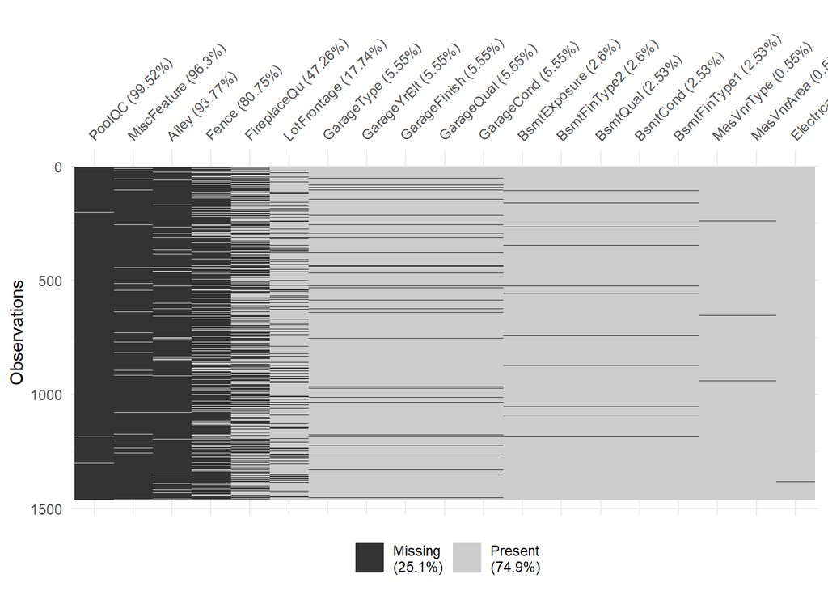

```r
train %>% select(train_miss_col$col_name) %>% vis_miss()
```

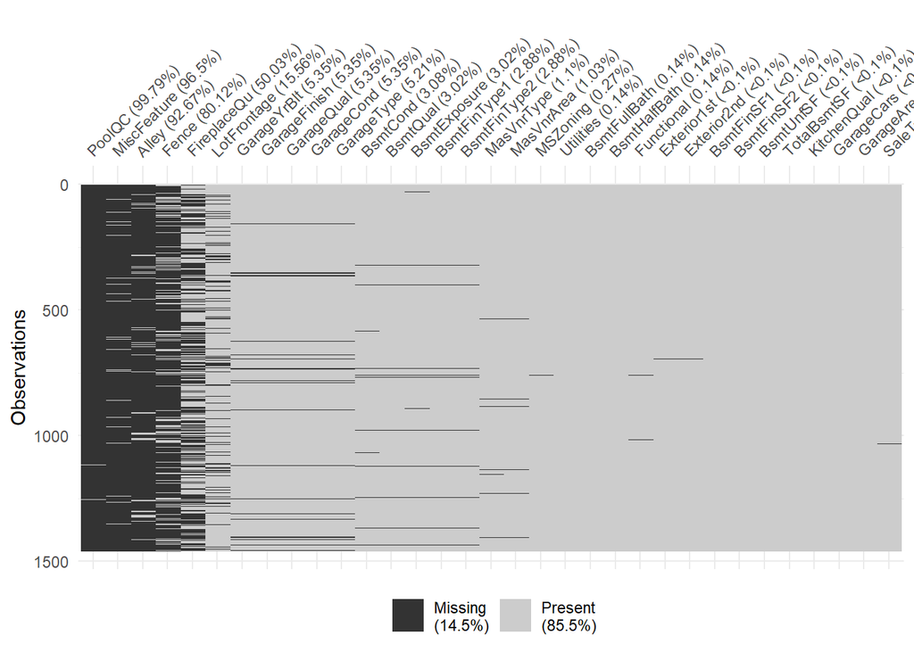

```r
test %>% select(test_miss_col$col_name) %>% vis_miss()
```

There are some tools and books for working with missing values:  
- [mice: Multivariate Imputation by Chained Equations](https://amices.org/mice/)  
- [missForest: Nonparametric Missing Value Imputation using Random Forest](https://cran.rstudio.com/web/packages/missForest/index.html)  
- [Hmisc: Harrell Miscellaneous](https://cran.r-project.org/web/packages/Hmisc/index.html)  
- [Book: Fexible Inputation of Missing Data(Stef van Buuren)](https://stefvanbuuren.name/fimd/)

People normally delete all of the columns having more than 30% of missing values. We can’t do it with this data. The reason is, with this data, the NAs can be actual missing values or “having no access”. Let’s move to the next part.

# 9 Working with NA that does not mean actual missing value

The above figures show that some columns having more than 90% of missing values. Check the Alley column (one of the columns having more than 90% missing values on the above figures) on the description file, the NAs can be actual missing values or “having no access”. For example, with the Alley column, NA means “No alley access”. However, we don’t see the value “None” in this column, which means that we have to change the NAs to “None”. We also need to check other columns

```r
unique_cha_name <- map(train %>% select_if(is_character), unique)
head(unique_cha_name)
>> $MSZoning
>> [1] "RL" "RM" "C"  "FV" "RH"
>>
>> $Street
>> [1] "Pave" "Grvl"
>>
>> $Alley
>> [1] NA     "Grvl" "Pave"
>>
>> $LotShape
>> [1] "Reg" "IR1" "IR2" "IR3"
>>
>> $LandContour
>> [1] "Lvl" "Bnk" "Low" "HLS"
>>
>> $Utilities
>> [1] "AllPub" "NoSeWa"
```

*The characteristic columns having values NA in the description file are the one that have NA means None*. Let’s consider all characteristics columns having NA in the values to see if NA is actually “missing values” or “having no access”.

Here are the column names of characteristic columns having NAs mean “None” (See the file [2_WorkWithDescriptionFile.Rmd](https://htmlpreview.github.io/?https://github.com/tranktle/ml_with_r_h2o/blob/main/ml_with_r_h2o/code/2_WorkWithDescriptionFile.html#2_Explain_the_two_functions_above) for the explanation about how to creating the function).

```r
The_char_colname <- find_col_name_f(des_file)
The_char_colname
>>  [1] "Alley"        "BsmtQual"     "BsmtCond"     "BsmtExposure" "BsmtFinType1"
>>  [6] "BsmtFinType2" "FireplaceQu"  "GarageType"   "GarageFinish" "GarageQual"
>> [11] "GarageCond"   "PoolQC"       "Fence"        "MiscFeature"
```

Now, we want to find numerical columns that are related to the characteristic columns having NA means “None”. We want to find these columns because, for example, a row having no Garage will have Garage_Area=0, so, the missing values in the column GarageArea that in the row with NA in the “Gara…” column should be imputed by 0.

```r
 find_vec <- c('Alley', 'Bsmt','Fire', 'Garage', 'Pool', 'Fence', 'Misc')
 pattern <- paste(find_vec, collapse="|")
 train_num_cols <- train %>% select_if(is.numeric) %>% colnames
 The_num_colname <- grep(pattern, train_num_cols,  value=TRUE)
 cat("Here are the numerical columns that have NA means 0 if the associative characteristic column also contains NA: \n \n", The_num_colname)
>> Here are the numerical columns that have NA means 0 if the associative characteristic column also contains NA:
>>
>>  BsmtFinSF1 BsmtFinSF2 BsmtUnfSF TotalBsmtSF BsmtFullBath BsmtHalfBath Fireplaces GarageYrBlt GarageCars GarageArea PoolArea MiscVal
```

## 9.1 Now, we want to impute the columns that have NA does not mean missing values.

- Up to now, we have:
  - The_char_colname: the characteristic columns having NAs mean None.
  - The_num_colname: the numerical columns having NA mean 0 if the related factorial columns have NAs in the same row

```r
cat("The_char_colname: \n ", The_char_colname, "\n\n")
>> The_char_colname:
>>   Alley BsmtQual BsmtCond BsmtExposure BsmtFinType1 BsmtFinType2 FireplaceQu GarageType GarageFinish GarageQual GarageCond PoolQC Fence MiscFeature
# des_file %>% filter(name %in% The_char_colname ) %>% select(c("name", "description"))
```

```r
cat("The_num_colname: \n ", The_num_colname)
>> The_num_colname:
>>   BsmtFinSF1 BsmtFinSF2 BsmtUnfSF TotalBsmtSF BsmtFullBath BsmtHalfBath Fireplaces GarageYrBlt GarageCars GarageArea PoolArea MiscVal
# des_file %>% filter(name %in% The_num_colname ) %>% select(c("name", "description"))
```

```r
# Uncomment to see the result
# Bsmt_col <- union(The_char_colname[str_which(The_char_colname, "Bsmt")], The_num_colname[str_which(The_num_colname, "Bsmt")])
# test_Bsmt_f <- function(set){
#   for (bs_col in Bsmt_col){
#   cat("when", bs_col, "has Na \n ")
#   print(sapply(set %>% filter(is.na(bs_col)) %>% select_if(names(.) %in% Bsmt_col),  function(x) sum(!is.na(x))))}
# }
#
# test_Bsmt_f(train)
# test_Bsmt_f(test)
```

```r
# # Uncomment to see the result
# Garage_col <- union(The_char_colname[str_which(The_char_colname, "Garage")], The_num_colname[str_which(The_num_colname, "Garage")])
# test_Garage_f <- function(set){
#   for (col in Garage_col){
#   cat("when", col, "has Na \n ")
#   print(sapply(set %>% filter(is.na(col)) %>% select_if(names(.) %in% Garage_col),  function(x) sum(!is.na(x))))}
# }
#
# test_Garage_f(train)
# test_Garage_f(test)
```

```r
# Uncomment to see the result
Pool_col <- union(The_char_colname[str_which(The_char_colname, "Pool")], The_num_colname[str_which(The_num_colname, "Pool")])
test_Pool_f <- function(set){
  for (col in Pool_col){
  cat("when", col, "has Na \n ")
  print(sapply(set %>% filter(is.na(col)) %>% select_if(names(.) %in% Pool_col),  function(x) sum(!is.na(x))))}
}

test_Pool_f(train)
>> when PoolQC has Na
>>  PoolArea   PoolQC
>>        0        0
>> when PoolArea has Na
>>  PoolArea   PoolQC
>>        0        0
test_Pool_f(test)
>> when PoolQC has Na
>>  PoolArea   PoolQC
>>        0        0
>> when PoolArea has Na
>>  PoolArea   PoolQC
>>        0        0
```

From the above observation, we will replace all NA in all characteristics columns by "None’, and in numerical columns by 0.

```r
# replace all NA of all characteristics columns by "None' and of numerical columns by 0
train <- train %>%
  mutate_if(names(.) %in% The_char_colname, replace_na, "None") %>%
  mutate_if(names(.) %in% The_num_colname, replace_na, 0)
test <- test %>%
  mutate_if(names(.) %in% The_char_colname, replace_na, "None") %>%
  mutate_if(names(.) %in% The_num_colname, replace_na, 0)
```

# 10 Recheck the missing values after some cleaning and impute the data sets

## 10.1 For the train set

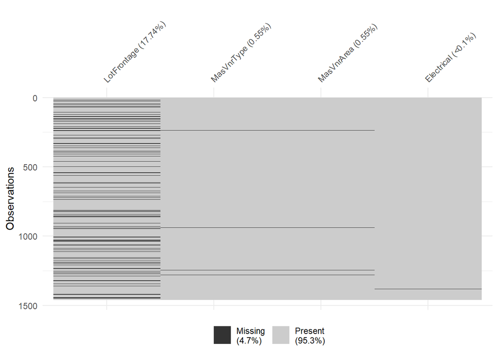

```r
train_miss_col <- mis_value_listing_f(train)
train %>% select(train_miss_col$col_name) %>% vis_miss()
```

```r
summary(train %>% select(train_miss_col$col_name))
>>   LotFrontage      MasVnrType          MasVnrArea      Electrical
>>  Min.   : 21.00   Length:1460        Min.   :   0.0   Length:1460
>>  1st Qu.: 59.00   Class :character   1st Qu.:   0.0   Class :character
>>  Median : 69.00   Mode  :character   Median :   0.0   Mode  :character
>>  Mean   : 70.05                      Mean   : 103.7
>>  3rd Qu.: 80.00                      3rd Qu.: 166.0
>>  Max.   :313.00                      Max.   :1600.0
>>  NA's   :259                         NA's   :8
```

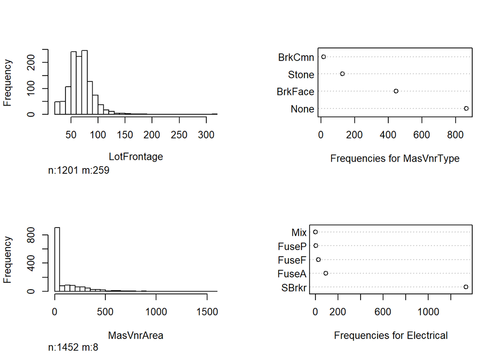

```r
hist.data.frame(train %>% select(train_miss_col$col_name))
```

## 10.2 For the test set

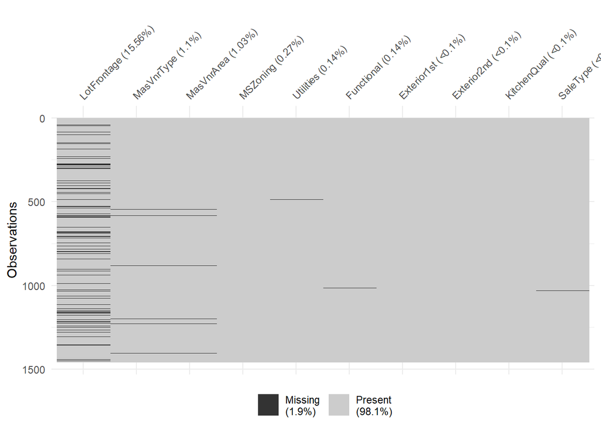

```r
test_miss_col  <- mis_value_listing_f(test)
test %>% select(test_miss_col$col_name) %>% vis_miss()
```

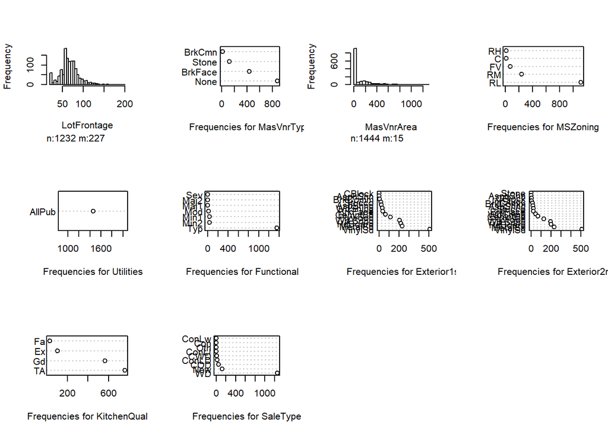

```r
summary(test %>% select(test_miss_col$col_name))
>>   LotFrontage      MasVnrType          MasVnrArea       MSZoning
>>  Min.   : 21.00   Length:1459        Min.   :   0.0   Length:1459
>>  1st Qu.: 58.00   Class :character   1st Qu.:   0.0   Class :character
>>  Median : 67.00   Mode  :character   Median :   0.0   Mode  :character
>>  Mean   : 68.58                      Mean   : 100.7
>>  3rd Qu.: 80.00                      3rd Qu.: 164.0
>>  Max.   :200.00                      Max.   :1290.0
>>  NA's   :227                         NA's   :15
>>   Utilities          Functional        Exterior1st        Exterior2nd
>>  Length:1459        Length:1459        Length:1459        Length:1459
>>  Class :character   Class :character   Class :character   Class :character
>>  Mode  :character   Mode  :character   Mode  :character   Mode  :character
>>
>>
>>
>>
>>  KitchenQual          SaleType
>>  Length:1459        Length:1459
>>  Class :character   Class :character
>>  Mode  :character   Mode  :character
>>
>>
>>
>>
hist.data.frame(test %>% select(test_miss_col$col_name))
```

## 10.3 Impute the missing columns

We will use mean for the numerical columns and use frequency for factorial columns. Again, the `imp_mean_fre_f`, like other functions used in this file, is in the `Utilities.R` file

```r
train <- imp_mean_fre_f(train, opt=1)
test <- imp_mean_fre_f(test, opt=1)
```

Now, there is no longer missing values in the sets

```r
sum(is.na(train))
>> [1] 0
sum(is.na(test))
>> [1] 0
```

Let’s delete the Id column out of the train and test sets since this column will not be useful for running models

```r
# check if train and test sets have any Id in common, we see that they have no id in common, this is actualy what we expected
intersect(train$Id, test$Id)
>> numeric(0)
# Delete Id out of train and test sets
train <- train %>% select(-Id)
test <- test %>% select(-Id)
```

# 11 As.factor all of characteritics columns

## 11.1 A way that we should NOT use to as.factor the characteristic columns

Here we will explain a way that we normally use, but we should not do. If you want, just skip this part and go to the next part which talks about the way that we should use.

We now want to as.factor all of the characteristic columns. The code chunk below gives a way that we normally do, but we should not do since in case our train and test sets have characteristics columns with many factor levels, it may cause the inconsistency between the level-set of train and test sets. Now let’s run the code chunk and see what will happen when we use it this way. (We name train_not_use and test_not_use for the data sets created when applying the way that we should not use to as.factor).

```r
train_not_use <- train %>%
         mutate_if(names(.) %in% char_col_name, as.factor)
test_not_use <- test %>%
         mutate_if(names(.) %in% char_col_name, as.factor)
```

The problem happens with the column name “MSSubClass” (and maybe some other columns). From the below, we see that level 150 is on the `test_not_use$MSSubClass` but the `test_not_use$MSSubClass`. This is because the as.factor function will take all of the unique values that are available in the data to create the level set and the `train$MSSubClass` set does not contain the value 150. When we use these data sets to run any model, we could not perform the prediction on the test set since the test set has a level that is not be trained yet.

```r
cat("levels of the train_not_use:", levels(train_not_use$MSSubClass), "\n")
>> levels of the train_not_use: 20 30 40 45 50 60 70 75 80 85 90 120 160 180 190
cat("levels of the test_not_use:", levels(test_not_use$MSSubClass), "\n")
>> levels of the test_not_use: 20 30 40 45 50 60 70 75 80 85 90 120 150 160 180 190
cat("the level that is in the test_not_use but train_not_use: ")
>> the level that is in the test_not_use but train_not_use:
setdiff(levels(test_not_use$MSSubClass),levels(train_not_use$MSSubClass))
>> [1] "150"
setdiff(levels(train_not_use$MSSubClass),levels(test_not_use$MSSubClass))
>> character(0)
```

## 11.2 A way that we could use to as.factor the characteristic columns without creating inconstistency between the level-sets of train and test set

I have tried some ways to deal with the problem mentioned in the previous part. This way is simple and seems to work well. We join the train and test sets to create a data set that combines train and test sets, as.factor the characteristic columns, and then separate them based on the fact that the train set has the output for “Saleprice” while the test set doesn’t.

```r
combine_dat <- bind_rows(train, test)
combine_dat <- combine_dat %>% mutate_if(names(.) %in% char_col_name, as.factor)
train <- combine_dat %>% filter(!is.na(SalePrice))
test  <- combine_dat %>% filter(is.na(SalePrice))
```

We can check that there is no different between the levels of all factorial columns between train and test sets:

```r
train_levels <-  map(train %>% select_if(is.factor), levels)
test_levels  <-  map(test %>% select_if(is.factor), levels)
cat("We see that there is no levels on the train set that is not on the test set and vice versa:")
>> We see that there is no levels on the train set that is not on the test set and vice versa:
train_levels[!(train_levels %in% test_levels)]
>> named list()
train_levels[!(train_levels %in% test_levels)]
>> named list()
```

Now, we have done cleaning data. Let’s save the data in the folder `house_dat` so that we can use it later on.

```r
write_rds(train, "../house_dat/clean_train.rds")
write_rds(test, "../house_dat/clean_test.rds")
```

I will soon have another post for applying AutoML using h2o package with the clean data 😏

# 12 Reference

[R for data Science](https://r4ds.had.co.nz/)  
[House Prices - Kaggle data set](https://www.kaggle.com/c/house-prices-advanced-regression-techniques)  
[Link to the project - my github](https://github.com/tranktle/ml_with_r_h2o). (You can download code files from the folder `ml_with_r-h2o`)